# Capsule Endoscopy Video Analytics

4Quant

July 24, 2015

# 1 Problem: Identifying Diseased Tissue in Capsule Endocopy Movies

Capsule endoscopy is a particularly innovative way for diagnosing a number of conditions without requiring surgical or otherwise invasive procedures. The self-contained capsule is simple swallowed and videos are recorded of the patients digestive track. The usual passing time of 24-48 hours means that a significant amount of video data is created for each patient and much of it is not diagnostically relevant. Viewing and finding the ‘needles’ in this haystack of data is very time consuming and can cause many minor details to be missed.

# 2 Solution: Image Query and Analysis Engine for Endoscopy Data

[figure not shown]

$\rightarrow$

[figure not shown]

$\downarrow$

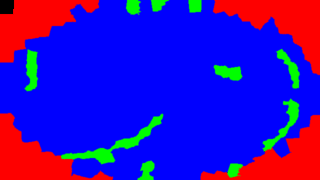

## 2.1 How?

The first question is how the data can be processed. The basic work is done by a simple workflow on top of our Spark Image Layer. This abstracts away the complexities of cloud computing and distributed analysis. You focus only on the core task of image processing.

[figure not shown]

Beyond a single camera, our system scales linearly to multiple cameras and can distribute this computation across many computers to keep the computation real-time.

[figure not shown]

## 2.2 What?

The images which are collected by the capsule continuously and converted into a video. We can then analyze each frame of the video to identify interesting sites.

[figure not shown]

The first step in this identification is to segment the frame into so-called superpixels, a standard technique for grouping similar regions together and makes examining textures and other parameters much easier.

[figure not shown]

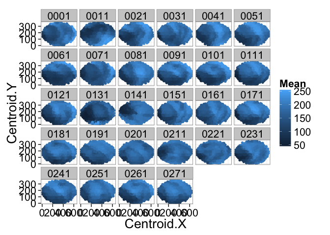

The data can be then analyzed in more detail to extract quantitatively meaningful metrics on the structure of the tissue.

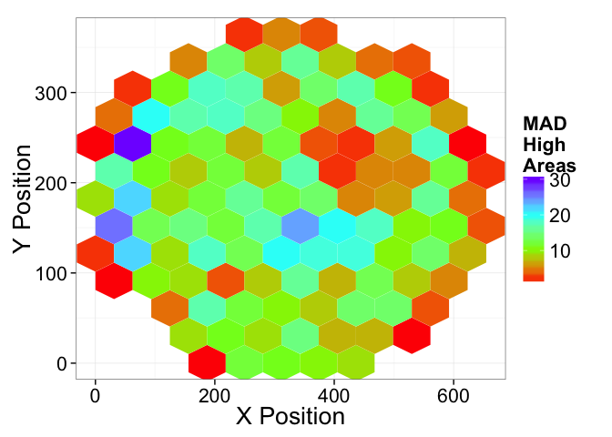

The quantitatively meaningful data can then be used to train machine learning algorithms (decision trees to SVM) in order to automatically high-light many of the interesting regions and label them as such, dratistically reducing the required time to analyze a single patient. Furthermore the ability to parallelize and scale means thousands to millions of videos can be analyzed at the same time to learn even more about the structures of the digestive track and identify new possibilities for diagnosis.

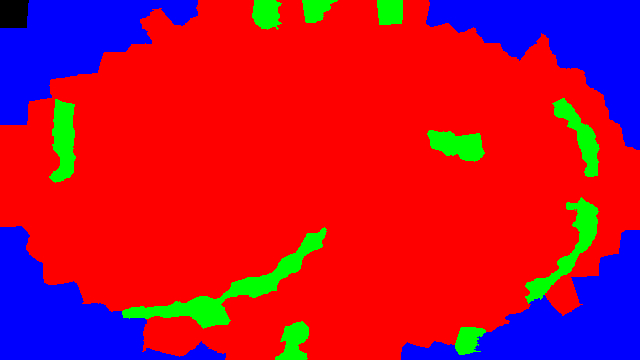

# 3 Technical Aspects

## 3.1 Streaming the Data

Once the cluster has been comissioned and you have the *StreamingSparkContext* called `ssc` (automatically provided in [Databricks Cloud](https://databricks.com/product/databricks-cloud) or [Zeppelin](http://zeppelin.incubator.apache.org)), the data can be loaded using the Spark Image Layer. Since we are using real-time analysis, we acquire the images from a streaming source

```scala
val trainCam1 = TrainCameraReceiver("sbb://train-3275")
val trainCam2 = TrainCameraReceiver("sbb://train-3187")
val metaImageStream = ssc.receiverStream(trainCam1 ++ trainCam2)
```

Although we execute the command on one machine, the analysis will be distributed over the entire set of cluster resources available to `ssc`. To further process the images, we can take advantage of the rich set of functionality built into Spark Image Layer

```scala
def identifyTracks(time: Double, pos: GeoPos, inImage: Img[Byte]) = {
  // Run the image processing steps on all images
  val rawTrack = inImage.
    run("Median...","radius=3"). // filter out the noise
    run("Tubeness..."). // highlight tube-like structures (tracks)
    run("Threshold","OTSU") // threshold bright structures
  val trackShape = rawTrack.
    componentLabel(). // identify the components of the track
    filter(_.area>50). // take only the larger sized
    shapeAnalysis() // analyze the position and shape
  // return smoothness and separation based on the segmented image
  TrackInformation(smoothness=rawTrack.smoothness(),
                   separation=calcSep(trackShape))
}
// apply the operation to all images as they come in
val trackStream = metaImageStream.map(identifyTracks)
```

The detailed information with time, position and track data can then be compared to reference values to find changes and alert the user

```scala
trackStream.foreachRDD{
  trackStream =>
    val changePoints = trackStream.
      join(trackStandards).
      filter{
        case(newData,oldResults) => abs(oldResults-newData)>0.05
      }.collect()
      // update the map
      updateMap(changePoints)
      // send an alert
      changePoints.map(
        (newPt,_) =>
          sendAlert(newPt.pos+" at "+newPt.time+" has changed by more then 5%")
      )
}
```

The entire pipeline can then be started to run in real-time on all the new images as they stream in. If the tasks become more computationally intensive, then the computing power can be scaled up and down elastically.

# 4 Acknowledgements

Analysis powered by Spark Image Layer from 4Quant, Visualizations, Document Generation, and Maps provided by:

To cite ggplot2 in publications, please use:

H. Wickham. ggplot2: elegant graphics for data analysis. Springer New York, 2009.

A BibTeX entry for LaTeX users is

To cite package ‘leaflet’ in publications use:

Joe Cheng and Yihui Xie (2014). leaflet: Create Interactive Web Maps with the JavaScript LeafLet Library. R package version 0.0.11. https://github.com/rstudio/leaflet

A BibTeX entry for LaTeX users is

To cite plyr in publications use:

Hadley Wickham (2011). The Split-Apply-Combine Strategy for Data Analysis. Journal of Statistical Software, 40(1), 1-29. URL http://www.jstatsoft.org/v40/i01/.

A BibTeX entry for LaTeX users is

To cite the ‘knitr’ package in publications use:

Yihui Xie (2015). knitr: A General-Purpose Package for Dynamic Report Generation in R. R package version 1.10.

Yihui Xie (2013) Dynamic Documents with R and knitr. Chapman and Hall/CRC. ISBN 978-1482203530

Yihui Xie (2014) knitr: A Comprehensive Tool for Reproducible Research in R. In Victoria Stodden, Friedrich Leisch and Roger D. Peng, editors, Implementing Reproducible Computational Research. Chapman and Hall/CRC. ISBN 978-1466561595

To cite package ‘rmarkdown’ in publications use:

JJ Allaire, Joe Cheng, Yihui Xie, Jonathan McPherson, Winston Chang, Jeff Allen, Hadley Wickham and Rob Hyndman (2015). rmarkdown: Dynamic Documents for R. R package version 0.7. http://CRAN.R-project.org/package=rmarkdown

A BibTeX entry for LaTeX users is

To cite package ‘DiagrammeR’ in publications use:

Knut Sveidqvist, Mike Bostock, Chris Pettitt, Mike Daines, Andrei Kashcha and Richard Iannone (2015). DiagrammeR: Create Graph Diagrams and Flowcharts Using R. R package version 0.7.

A BibTeX entry for LaTeX users is